# Capstone Project : Part.1

This capstone project is Home credit Default risk's classification problem: The label is a binary variable, 0 will repay loan on time, 1 will have difficulty repaying loan

## Introduction

This dataset have 7 different sources of data:

- application_train/application_test: the main training and testing data with information about each loan application at Home Credit. Every loan has its own row and is identified by the feature SK_ID_CURR. The training application data comes with the TARGET indicating 0: the loan was repaid or 1: the loan was not repaid.
- bureau: data concerning client's previous credits from other financial institutions. Each previous credit has its own row in bureau, but one loan in the application data can have multiple previous credits.
- bureau_balance: monthly data about the previous credits in bureau. Each row is one month of a previous credit, and a single previous credit can have multiple rows, one for each month of the credit length.
- previous_application: previous applications for loans at Home Credit of clients who have loans in the application data. Each current loan in the application data can have multiple previous loans. Each previous application has one row and is identified by the feature SK_ID_PREV.
- POS_CASH_BALANCE: monthly data about previous point of sale or cash loans clients have had with Home Credit. Each row is one month of a previous point of sale or cash loan, and a single previous loan can have many rows.
- credit_card_balance: monthly data about previous credit cards clients have had with Home Credit. Each row is one month of a credit card balance, and a single credit card can have many rows.
- installments_payment: payment history for previous loans at Home Credit. There is one row for every made payment and one row for every missed payment.

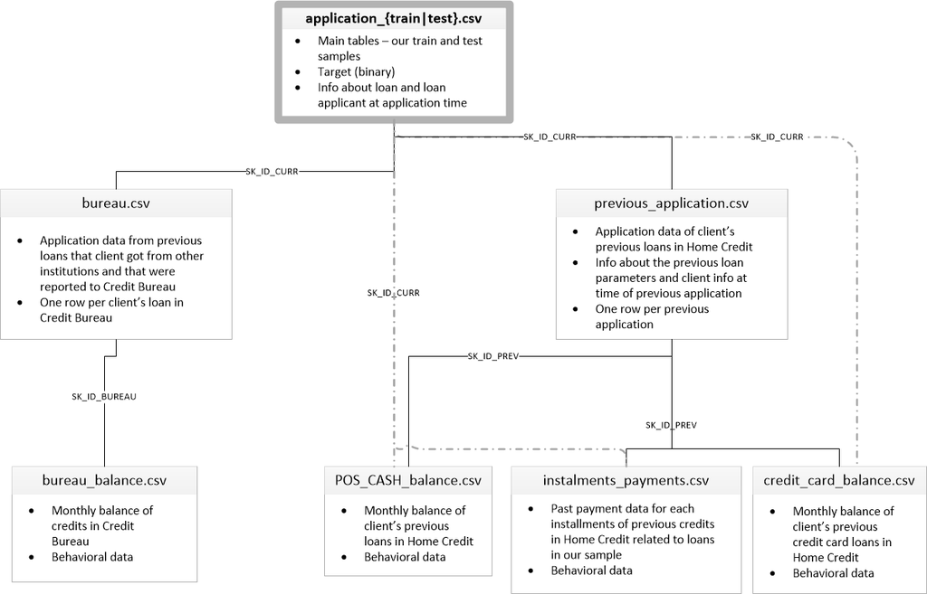

```python
from IPython.display import Image
Image(filename = 'dataset/home_credit.png')
```

```python
import pandas as pd
import numpy as np
import seaborn as sns
import matplotlib.pyplot as plt
%matplotlib inline
# File system management
import os
import warnings

warnings.filterwarnings('ignore')

descripstion = pd.read_csv('data_set/HomeCredit_columns_description.csv')
descripstion.head()
```

|  | Unnamed: 0 | Table | Row | Description | Special |
| --- | --- | --- | --- | --- | --- |
| 0 | 1 | application_{train\|test}.csv | SK_ID_CURR | ID of loan in our sample | NaN |
| 1 | 2 | application_{train\|test}.csv | TARGET | Target variable (1 - client with payment diffi... | NaN |
| 2 | 5 | application_{train\|test}.csv | NAME_CONTRACT_TYPE | Identification if loan is cash or revolving | NaN |
| 3 | 6 | application_{train\|test}.csv | CODE_GENDER | Gender of the client | NaN |
| 4 | 7 | application_{train\|test}.csv | FLAG_OWN_CAR | Flag if the client owns a car | NaN |

The 'HomeCredit_columns_description.csv' file which indecate the definition of all the columns in dataset and an example of the expected submission file.

## EDA: Exploratory Data Analysis

```python
print(os.listdir('data_set/'))
```

```
['application_test.csv', 'HomeCredit_columns_description.csv', 'home_credit.png', 'POS_CASH_balance.csv', 'credit_card_balance.csv', 'installments_payments.csv', 'application_train.csv', 'bureau.csv', 'previous_application.csv', 'bureau_balance.csv', 'sample_submission.csv']
```

### 1. application_train\test

##### Training data

```python
app_train = pd.read_csv('data_set/application_train.csv')
app_train.shape
# Observations: 307511, featues: 122
```

```
(307511, 122)
```

```python
app_train.head()
```

|  | SK_ID_CURR | TARGET | NAME_CONTRACT_TYPE | CODE_GENDER | FLAG_OWN_CAR | FLAG_OWN_REALTY | CNT_CHILDREN | AMT_INCOME_TOTAL | AMT_CREDIT | AMT_ANNUITY | ... | FLAG_DOCUMENT_18 | FLAG_DOCUMENT_19 | FLAG_DOCUMENT_20 | FLAG_DOCUMENT_21 | AMT_REQ_CREDIT_BUREAU_HOUR | AMT_REQ_CREDIT_BUREAU_DAY | AMT_REQ_CREDIT_BUREAU_WEEK | AMT_REQ_CREDIT_BUREAU_MON | AMT_REQ_CREDIT_BUREAU_QRT | AMT_REQ_CREDIT_BUREAU_YEAR |
| --- | --- | --- | --- | --- | --- | --- | --- | --- | --- | --- | --- | --- | --- | --- | --- | --- | --- | --- | --- | --- | --- |
| 0 | 100002 | 1 | Cash loans | M | N | Y | 0 | 202500.0 | 406597.5 | 24700.5 | ... | 0 | 0 | 0 | 0 | 0.0 | 0.0 | 0.0 | 0.0 | 0.0 | 1.0 |
| 1 | 100003 | 0 | Cash loans | F | N | N | 0 | 270000.0 | 1293502.5 | 35698.5 | ... | 0 | 0 | 0 | 0 | 0.0 | 0.0 | 0.0 | 0.0 | 0.0 | 0.0 |
| 2 | 100004 | 0 | Revolving loans | M | Y | Y | 0 | 67500.0 | 135000.0 | 6750.0 | ... | 0 | 0 | 0 | 0 | 0.0 | 0.0 | 0.0 | 0.0 | 0.0 | 0.0 |
| 3 | 100006 | 0 | Cash loans | F | N | Y | 0 | 135000.0 | 312682.5 | 29686.5 | ... | 0 | 0 | 0 | 0 | NaN | NaN | NaN | NaN | NaN | NaN |
| 4 | 100007 | 0 | Cash loans | M | N | Y | 0 | 121500.0 | 513000.0 | 21865.5 | ... | 0 | 0 | 0 | 0 | 0.0 | 0.0 | 0.0 | 0.0 | 0.0 | 0.0 |

5 rows × 122 columns

##### Testing data

```python
app_test = pd.read_csv('data_set/application_test.csv')
app_test.shape
# Observations: 48744, features: 121
```

```
(48744, 121)
```

```python
app_test.head()
```

|  | SK_ID_CURR | NAME_CONTRACT_TYPE | CODE_GENDER | FLAG_OWN_CAR | FLAG_OWN_REALTY | CNT_CHILDREN | AMT_INCOME_TOTAL | AMT_CREDIT | AMT_ANNUITY | AMT_GOODS_PRICE | ... | FLAG_DOCUMENT_18 | FLAG_DOCUMENT_19 | FLAG_DOCUMENT_20 | FLAG_DOCUMENT_21 | AMT_REQ_CREDIT_BUREAU_HOUR | AMT_REQ_CREDIT_BUREAU_DAY | AMT_REQ_CREDIT_BUREAU_WEEK | AMT_REQ_CREDIT_BUREAU_MON | AMT_REQ_CREDIT_BUREAU_QRT | AMT_REQ_CREDIT_BUREAU_YEAR |
| --- | --- | --- | --- | --- | --- | --- | --- | --- | --- | --- | --- | --- | --- | --- | --- | --- | --- | --- | --- | --- | --- |
| 0 | 100001 | Cash loans | F | N | Y | 0 | 135000.0 | 568800.0 | 20560.5 | 450000.0 | ... | 0 | 0 | 0 | 0 | 0.0 | 0.0 | 0.0 | 0.0 | 0.0 | 0.0 |
| 1 | 100005 | Cash loans | M | N | Y | 0 | 99000.0 | 222768.0 | 17370.0 | 180000.0 | ... | 0 | 0 | 0 | 0 | 0.0 | 0.0 | 0.0 | 0.0 | 0.0 | 3.0 |
| 2 | 100013 | Cash loans | M | Y | Y | 0 | 202500.0 | 663264.0 | 69777.0 | 630000.0 | ... | 0 | 0 | 0 | 0 | 0.0 | 0.0 | 0.0 | 0.0 | 1.0 | 4.0 |
| 3 | 100028 | Cash loans | F | N | Y | 2 | 315000.0 | 1575000.0 | 49018.5 | 1575000.0 | ... | 0 | 0 | 0 | 0 | 0.0 | 0.0 | 0.0 | 0.0 | 0.0 | 3.0 |
| 4 | 100038 | Cash loans | M | Y | N | 1 | 180000.0 | 625500.0 | 32067.0 | 625500.0 | ... | 0 | 0 | 0 | 0 | NaN | NaN | NaN | NaN | NaN | NaN |

5 rows × 121 columns

```
0    282686
1     24825
Name: TARGET, dtype: int64
```

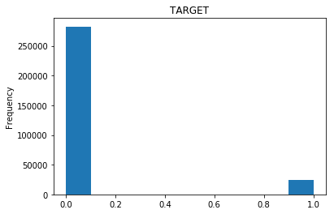

```python
# Number of loans falling into each category (0 will repay loan on thime, 1 is that client had payment difficulties)

print(app_train.TARGET.value_counts())
app_train.TARGET.astype(int).plot.hist(title='TARGET');
```

```
Missing value: 96391, Percent of total missing : 31%
```

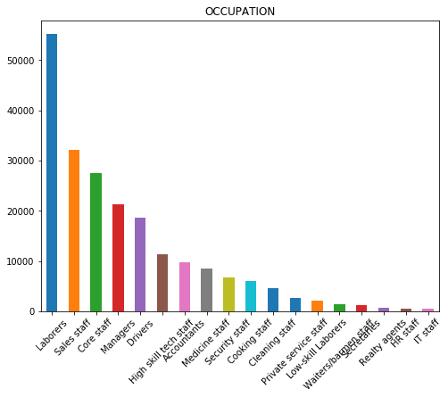

```python
# Client's Occupation type
app_train.OCCUPATION_TYPE.value_counts().plot(kind='bar', rot=45, figsize=(8,6), title='OCCUPATION');

def missing_values_percent(data):
    miss_val = data.isnull().sum()
    miss_val_percent = 100 * data.isnull().sum() / len(data)
    print('Missing value: {}, Percent of total missing : {}% '. format(miss_val, miss_val_percent, ))

missing_values_percent(app_train.OCCUPATION_TYPE)
```

```
Missing value: 0, Percent of total missing : 0%
```

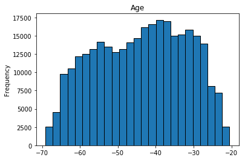

```python
# Distribution of Age
Age = (app_train.DAYS_BIRTH / 365)
Age.plot.hist(edgecolor = 'k', bins = 25, title='Age');

missing_values_percent(app_train.DAYS_BIRTH)
```

To visualize the effect of the age on the target, we will next make a kernel density estimation plot (KDE) colored by the value of the target. KDE plot shows the distribution of a single variable and can be thought of as a smoothed histogram.

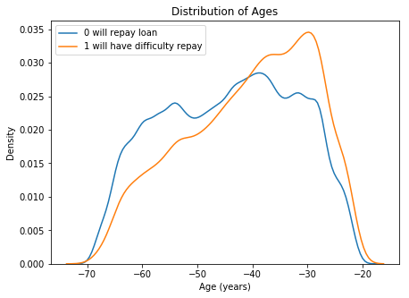

```python
# Plotting KDE plot
plt.figure(figsize = (7, 5))
sns.kdeplot(app_train.loc[app_train['TARGET'] == 0, 'DAYS_BIRTH'] / 365, label = '0 will repay loan')
sns.kdeplot(app_train.loc[app_train['TARGET'] == 1, 'DAYS_BIRTH'] / 365, label = '1 will have difficulty repay')
plt.xlabel('Age (years)'); plt.ylabel('Density'); plt.title('Distribution of Ages');
```

```
Missing value: 0, Percent of total missing : 0%
```

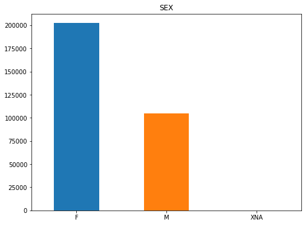

```python
# Plotting CODE_GENDER
app_train.CODE_GENDER.value_counts().plot(kind='bar', rot=0, figsize=(8,6), title='SEX');
missing_values_percent(app_train.CODE_GENDER)
```

```
Missing value: 0, Percent of total missing : 0%
```

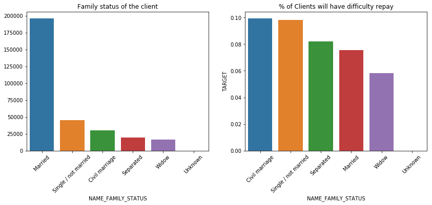

```python
# Look at the famali's status with Clients will repay loan or not
def plot_stats(data):
    plt.figure(figsize = [14,5])

    plt.subplot(1,2,1)
    family_sta = app_train.NAME_FAMILY_STATUS.value_counts()
    sns.barplot(x = family_sta.index, y=family_sta.values)
    plt.title("Family status of the client")
    plt.xlabel(data.name)
    plt.xticks(rotation=45)

    plt.subplot(1,2,2)
    #Calculate the percentage of target=1 per category value
    cat_perc = app_train[[data.name, 'TARGET']].groupby([data.name],as_index=False).mean()
    cat_perc.sort_values(by='TARGET', ascending=False, inplace=True)
    sns.barplot( x = data.name, y='TARGET', order=cat_perc[data.name], data=cat_perc)
    plt.title('% of Clients will have difficulty repay')
    plt.xticks(rotation=45)

plot_stats(app_train.NAME_FAMILY_STATUS)
missing_values_percent(app_train.NAME_FAMILY_STATUS)
```

```
Missing value: 0, Percent of total missing : 0%
```

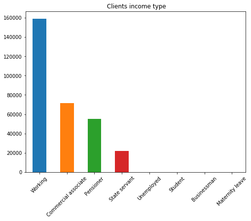

```python
# Checking Clients income type (businessman, working, maternity leave,…)
app_train.NAME_INCOME_TYPE.value_counts().plot(kind='bar', rot=45, figsize=(8,6), title= ' Clients income type' );
missing_values_percent(app_train.NAME_INCOME_TYPE)
```

```
Missing value: 0, Percent of total missing : 0%
```

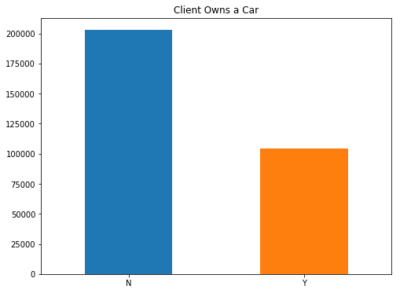

```python
# Check the client owns a car
app_train.FLAG_OWN_CAR.value_counts().plot(kind='bar', rot=0, figsize=(8,6), title='Client Owns a Car');
missing_values_percent(app_train.FLAG_OWN_CAR)
```

```
Missing value: 0, Percent of total missing : 0%
```

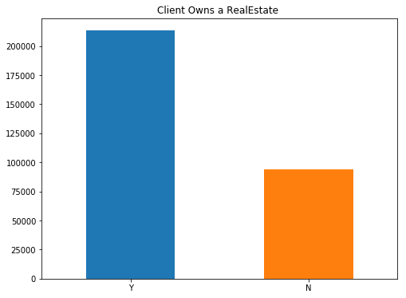

```python
# Look at the client's own real estate
app_train.FLAG_OWN_REALTY.value_counts().plot(kind='bar', rot=0, figsize=(8,6), title='Client Owns a RealEstate ');
missing_values_percent(app_train.FLAG_OWN_REALTY)
```

```
('mean of amount credit: ', 599025.9997057016)
Missing value: 0, Percent of total missing : 0%
```

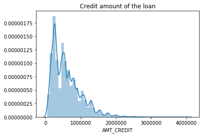

```python
# Amount of credit :
sns.distplot(app_train['AMT_CREDIT'], kde=True).set_title("Credit amount of the loan")
print("mean of amount credit: ", app_train['AMT_CREDIT'].mean())
missing_values_percent(app_train.AMT_CREDIT)
```

This chart is the credit amount of the loan

```
('mean of annuity: ', 27108.573909183444)
Missing value: 12, Percent of total missing : 0%
```

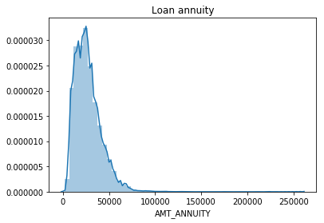

```python
# Auunity
sns.distplot(app_train.loc[app_train.AMT_ANNUITY.notnull()]['AMT_ANNUITY'], kde=True).set_title('Loan annuity')
print("mean of annuity: ", app_train.loc[app_train.AMT_ANNUITY.notnull()]['AMT_ANNUITY'].mean())
missing_values_percent(app_train.AMT_ANNUITY)
```

```
Missing value: 0, Percent of total missing : 0%
```

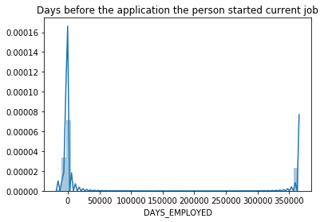

```python
# Days employed
sns.distplot(app_train.loc[app_train.DAYS_EMPLOYED.notnull()]['DAYS_EMPLOYED'], kde=True).set_title('Days before the application the person started current job')
missing_values_percent(app_train.DAYS_EMPLOYED)
```

Days employed indecate that how many days before the application the person started current employment.

```python
# Number of unique classes in each object column
app_train.select_dtypes('object').apply(pd.Series.nunique, axis = 0)
```

```
NAME_CONTRACT_TYPE             2
CODE_GENDER                    3
FLAG_OWN_CAR                   2
FLAG_OWN_REALTY                2
NAME_TYPE_SUITE                7
NAME_INCOME_TYPE               8
NAME_EDUCATION_TYPE            5
NAME_FAMILY_STATUS             6
NAME_HOUSING_TYPE              6
OCCUPATION_TYPE               18
WEEKDAY_APPR_PROCESS_START     7
ORGANIZATION_TYPE             58
FONDKAPREMONT_MODE             4
HOUSETYPE_MODE                 3
WALLSMATERIAL_MODE             7
EMERGENCYSTATE_MODE            2
dtype: int64
```

### 2. bureau / bureau_balance

##### bureau

```python
bureau = pd.read_csv('data_set/bureau.csv')
bureau.shape
```

```
(1716428, 17)
```

```python
bureau.head()
```

|  | SK_ID_CURR | SK_ID_BUREAU | CREDIT_ACTIVE | CREDIT_CURRENCY | DAYS_CREDIT | CREDIT_DAY_OVERDUE | DAYS_CREDIT_ENDDATE | DAYS_ENDDATE_FACT | AMT_CREDIT_MAX_OVERDUE | CNT_CREDIT_PROLONG | AMT_CREDIT_SUM | AMT_CREDIT_SUM_DEBT | AMT_CREDIT_SUM_LIMIT | AMT_CREDIT_SUM_OVERDUE | CREDIT_TYPE | DAYS_CREDIT_UPDATE | AMT_ANNUITY |
| --- | --- | --- | --- | --- | --- | --- | --- | --- | --- | --- | --- | --- | --- | --- | --- | --- | --- |
| 0 | 215354 | 5714462 | Closed | currency 1 | -497 | 0 | -153.0 | -153.0 | NaN | 0 | 91323.0 | 0.0 | NaN | 0.0 | Consumer credit | -131 | NaN |
| 1 | 215354 | 5714463 | Active | currency 1 | -208 | 0 | 1075.0 | NaN | NaN | 0 | 225000.0 | 171342.0 | NaN | 0.0 | Credit card | -20 | NaN |
| 2 | 215354 | 5714464 | Active | currency 1 | -203 | 0 | 528.0 | NaN | NaN | 0 | 464323.5 | NaN | NaN | 0.0 | Consumer credit | -16 | NaN |
| 3 | 215354 | 5714465 | Active | currency 1 | -203 | 0 | NaN | NaN | NaN | 0 | 90000.0 | NaN | NaN | 0.0 | Credit card | -16 | NaN |
| 4 | 215354 | 5714466 | Active | currency 1 | -629 | 0 | 1197.0 | NaN | 77674.5 | 0 | 2700000.0 | NaN | NaN | 0.0 | Consumer credit | -21 | NaN |

```python
bureau.info()
```

```
<class 'pandas.core.frame.DataFrame'>
RangeIndex: 1716428 entries, 0 to 1716427
Data columns (total 17 columns):
SK_ID_CURR                int64
SK_ID_BUREAU              int64
CREDIT_ACTIVE             object
CREDIT_CURRENCY           object
DAYS_CREDIT               int64
CREDIT_DAY_OVERDUE        int64
DAYS_CREDIT_ENDDATE       float64
DAYS_ENDDATE_FACT         float64
AMT_CREDIT_MAX_OVERDUE    float64
CNT_CREDIT_PROLONG        int64
AMT_CREDIT_SUM            float64
AMT_CREDIT_SUM_DEBT       float64
AMT_CREDIT_SUM_LIMIT      float64
AMT_CREDIT_SUM_OVERDUE    float64
CREDIT_TYPE               object
DAYS_CREDIT_UPDATE        int64
AMT_ANNUITY               float64
dtypes: float64(8), int64(6), object(3)
memory usage: 222.6+ MB
```

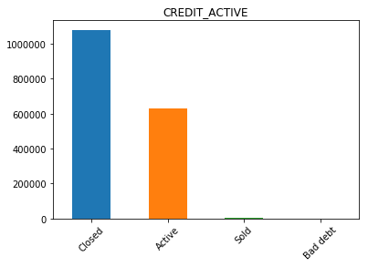

```python
# Status of the Credit Bureau (CB) reported credits
bureau.CREDIT_ACTIVE.value_counts()[:5].plot(kind='bar', rot=45, title='CREDIT_ACTIVE');
```

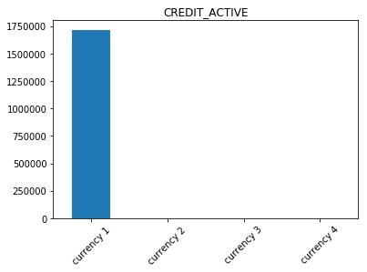

```python
# Recoded currency of the Credit Bureau credit
bureau.CREDIT_CURRENCY.value_counts()[:5].plot(kind='bar', rot=45, title='CREDIT_ACTIVE');
```

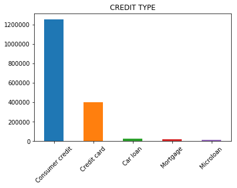

```python
# Type of Credit Bureau credit
bureau.CREDIT_TYPE.value_counts()[:5].plot(kind='bar', rot=45, title='CREDIT TYPE');
```

##### bureau_balance

```python
bureau_balance = pd.read_csv('data_set/bureau_balance.csv')
bureau_balance.shape
```

```
(27299925, 3)
```

```python
bureau_balance.head()
```

|  | SK_ID_BUREAU | MONTHS_BALANCE | STATUS |
| --- | --- | --- | --- |
| 0 | 5715448 | 0 | C |
| 1 | 5715448 | -1 | C |
| 2 | 5715448 | -2 | C |
| 3 | 5715448 | -3 | C |
| 4 | 5715448 | -4 | C |

```python
bureau_balance.MONTHS_BALANCE.unique()
```

```
array([  0,  -1,  -2,  -3,  -4,  -5,  -6,  -7,  -8,  -9, -10, -11, -12,
       -13, -14, -15, -16, -17, -18, -19, -20, -21, -22, -23, -24, -25,
       -26, -27, -28, -29, -30, -31, -32, -33, -34, -35, -36, -37, -38,
       -39, -40, -41, -42, -43, -44, -45, -46, -47, -48, -49, -50, -51,
       -52, -53, -54, -55, -56, -57, -58, -59, -60, -61, -62, -63, -64,
       -65, -66, -67, -68, -69, -70, -71, -72, -73, -74, -75, -76, -77,
       -78, -79, -80, -81, -82, -83, -84, -85, -86, -87, -88, -89, -90,
       -91, -92, -93, -94, -95, -96])
```

```python
bureau_balance.STATUS.unique()
```

```
array(['C', '0', 'X', '1', '2', '3', '5', '4'], dtype=object)
```

### 3. POS_CASH_balance, credit_card_balance, installments_payments, previous_application

##### POS_CASH_balance

```python
pos_cash = pd.read_csv('data_set/POS_CASH_balance.csv')
pos_cash.shape
```

```
(10001358, 8)
```

```python
pos_cash.head()
```

|  | SK_ID_PREV | SK_ID_CURR | MONTHS_BALANCE | CNT_INSTALMENT | CNT_INSTALMENT_FUTURE | NAME_CONTRACT_STATUS | SK_DPD | SK_DPD_DEF |
| --- | --- | --- | --- | --- | --- | --- | --- | --- |
| 0 | 1803195 | 182943 | -31 | 48.0 | 45.0 | Active | 0 | 0 |
| 1 | 1715348 | 367990 | -33 | 36.0 | 35.0 | Active | 0 | 0 |
| 2 | 1784872 | 397406 | -32 | 12.0 | 9.0 | Active | 0 | 0 |
| 3 | 1903291 | 269225 | -35 | 48.0 | 42.0 | Active | 0 | 0 |
| 4 | 2341044 | 334279 | -35 | 36.0 | 35.0 | Active | 0 | 0 |

```python
def missing_dataframe(data):
    null_data = data.isnull().sum()
    percent = (100 * null_data /  len(data)).sort_values(ascending = False)
    return pd.concat([null_data.sort_values(ascending = False), percent], axis = 1, keys = ['Total_miss', 'Percent'])

missing_dataframe(pos_cash)
```

|  | Total_miss | Percent |
| --- | --- | --- |
| CNT_INSTALMENT_FUTURE | 26087 | 0.260835 |
| CNT_INSTALMENT | 26071 | 0.260675 |
| SK_DPD_DEF | 0 | 0.000000 |
| SK_DPD | 0 | 0.000000 |
| NAME_CONTRACT_STATUS | 0 | 0.000000 |
| MONTHS_BALANCE | 0 | 0.000000 |
| SK_ID_CURR | 0 | 0.000000 |
| SK_ID_PREV | 0 | 0.000000 |

##### Previous_application

```python
previous_app =  pd.read_csv('data_set/previous_application.csv')
previous_app.shape
```

```
(1670214, 37)
```

```python
previous_app.head()
```

|  | SK_ID_PREV | SK_ID_CURR | NAME_CONTRACT_TYPE | AMT_ANNUITY | AMT_APPLICATION | AMT_CREDIT | AMT_DOWN_PAYMENT | AMT_GOODS_PRICE | WEEKDAY_APPR_PROCESS_START | HOUR_APPR_PROCESS_START | ... | NAME_SELLER_INDUSTRY | CNT_PAYMENT | NAME_YIELD_GROUP | PRODUCT_COMBINATION | DAYS_FIRST_DRAWING | DAYS_FIRST_DUE | DAYS_LAST_DUE_1ST_VERSION | DAYS_LAST_DUE | DAYS_TERMINATION | NFLAG_INSURED_ON_APPROVAL |
| --- | --- | --- | --- | --- | --- | --- | --- | --- | --- | --- | --- | --- | --- | --- | --- | --- | --- | --- | --- | --- | --- |
| 0 | 2030495 | 271877 | Consumer loans | 1730.430 | 17145.0 | 17145.0 | 0.0 | 17145.0 | SATURDAY | 15 | ... | Connectivity | 12.0 | middle | POS mobile with interest | 365243.0 | -42.0 | 300.0 | -42.0 | -37.0 | 0.0 |
| 1 | 2802425 | 108129 | Cash loans | 25188.615 | 607500.0 | 679671.0 | NaN | 607500.0 | THURSDAY | 11 | ... | XNA | 36.0 | low_action | Cash X-Sell: low | 365243.0 | -134.0 | 916.0 | 365243.0 | 365243.0 | 1.0 |
| 2 | 2523466 | 122040 | Cash loans | 15060.735 | 112500.0 | 136444.5 | NaN | 112500.0 | TUESDAY | 11 | ... | XNA | 12.0 | high | Cash X-Sell: high | 365243.0 | -271.0 | 59.0 | 365243.0 | 365243.0 | 1.0 |
| 3 | 2819243 | 176158 | Cash loans | 47041.335 | 450000.0 | 470790.0 | NaN | 450000.0 | MONDAY | 7 | ... | XNA | 12.0 | middle | Cash X-Sell: middle | 365243.0 | -482.0 | -152.0 | -182.0 | -177.0 | 1.0 |
| 4 | 1784265 | 202054 | Cash loans | 31924.395 | 337500.0 | 404055.0 | NaN | 337500.0 | THURSDAY | 9 | ... | XNA | 24.0 | high | Cash Street: high | NaN | NaN | NaN | NaN | NaN | NaN |

5 rows × 37 columns

```python
missing_dataframe(previous_app).head(20)
```

|  | Total_miss | Percent |
| --- | --- | --- |
| RATE_INTEREST_PRIVILEGED | 1664263 | 99.643698 |
| RATE_INTEREST_PRIMARY | 1664263 | 99.643698 |
| RATE_DOWN_PAYMENT | 895844 | 53.636480 |
| AMT_DOWN_PAYMENT | 895844 | 53.636480 |
| NAME_TYPE_SUITE | 820405 | 49.119754 |
| DAYS_TERMINATION | 673065 | 40.298129 |
| NFLAG_INSURED_ON_APPROVAL | 673065 | 40.298129 |
| DAYS_FIRST_DRAWING | 673065 | 40.298129 |
| DAYS_FIRST_DUE | 673065 | 40.298129 |
| DAYS_LAST_DUE_1ST_VERSION | 673065 | 40.298129 |
| DAYS_LAST_DUE | 673065 | 40.298129 |
| AMT_GOODS_PRICE | 385515 | 23.081773 |
| AMT_ANNUITY | 372235 | 22.286665 |
| CNT_PAYMENT | 372230 | 22.286366 |
| PRODUCT_COMBINATION | 346 | 0.020716 |
| AMT_CREDIT | 1 | 0.000060 |
| SK_ID_CURR | 0 | 0.000000 |
| NAME_CONTRACT_TYPE | 0 | 0.000000 |
| WEEKDAY_APPR_PROCESS_START | 0 | 0.000000 |
| HOUR_APPR_PROCESS_START | 0 | 0.000000 |

[output not shown]

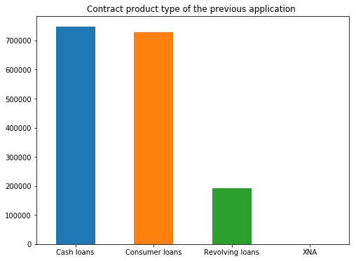

```python
# Look at the client's own real estate
previous_app.NAME_CONTRACT_TYPE.value_counts().plot(kind='bar', rot=0, figsize=(8,6), title='Contract product type of the previous application ');
```

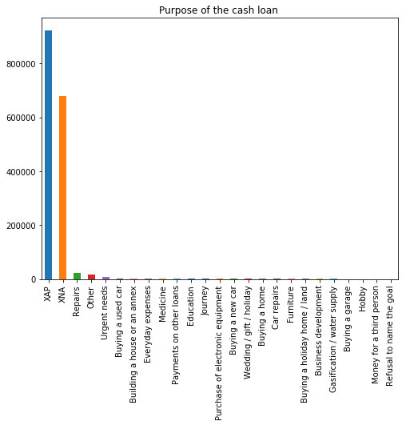

```python
# Checking Client's purpose fo the cash loan
previous_app.NAME_CASH_LOAN_PURPOSE.value_counts().plot(kind='bar', rot=90, figsize=(8,6), title='Purpose of the cash loan ')
```

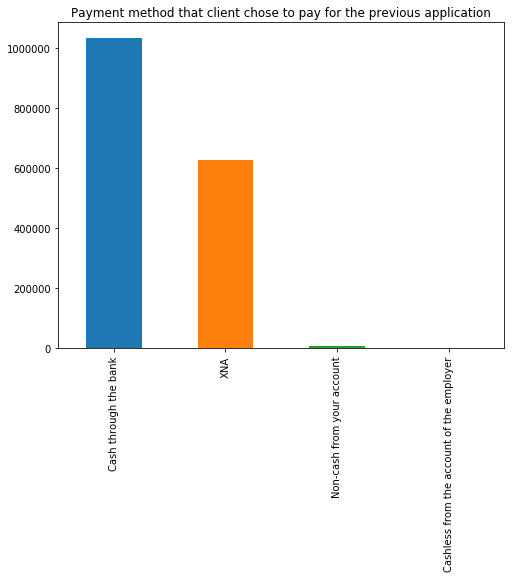

```python
# Look at Client's payment type
previous_app.NAME_PAYMENT_TYPE.value_counts().plot(kind='bar', rot=90, figsize=(8,6), title='Payment method that client chose to pay for the previous application')
```

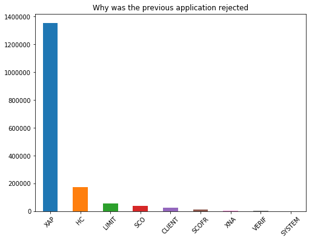

```python
# XAP is not applicable (i.e. a consumer loan has no cash_loan_purpose)
previous_app.CODE_REJECT_REASON.value_counts().plot(kind='bar', rot=45, figsize=(8,6), title='Why was the previous application rejected')
```

##### installments_payments

```python
installments_pay = pd.read_csv('data_set/installments_payments.csv')
installments_pay.shape
```

```
(1736093, 8)
```

```python
installments_pay.head()
```

|  | SK_ID_PREV | SK_ID_CURR | NUM_INSTALMENT_VERSION | NUM_INSTALMENT_NUMBER | DAYS_INSTALMENT | DAYS_ENTRY_PAYMENT | AMT_INSTALMENT | AMT_PAYMENT |
| --- | --- | --- | --- | --- | --- | --- | --- | --- |
| 0 | 1054186 | 161674.0 | 1.0 | 6.0 | -1180.0 | -1187.0 | 6948.360 | 6948.360 |
| 1 | 1330831 | 151639.0 | 0.0 | 34.0 | -2156.0 | -2156.0 | 1716.525 | 1716.525 |
| 2 | 2085231 | 193053.0 | 2.0 | 1.0 | -63.0 | -63.0 | 25425.000 | 25425.000 |
| 3 | 2452527 | 199697.0 | 1.0 | 3.0 | -2418.0 | -2426.0 | 24350.130 | 24350.130 |
| 4 | 2714724 | 167756.0 | 1.0 | 2.0 | -1383.0 | -1366.0 | 2165.040 | 2160.585 |

```python
# Check missing value rates in installments_payments.csv
missing_dataframe(installments_pay)
```

|  | Total_miss | Percent |
| --- | --- | --- |
| AMT_PAYMENT | 1 | 0.000058 |
| AMT_INSTALMENT | 1 | 0.000058 |
| DAYS_ENTRY_PAYMENT | 1 | 0.000058 |
| DAYS_INSTALMENT | 1 | 0.000058 |
| NUM_INSTALMENT_NUMBER | 1 | 0.000058 |
| NUM_INSTALMENT_VERSION | 1 | 0.000058 |
| SK_ID_CURR | 1 | 0.000058 |
| SK_ID_PREV | 0 | 0.000000 |

##### credit_card_balance

```python
credit_card = pd.read_csv('data_set/credit_card_balance.csv')
credit_card.shape
```

```
(3840312, 23)
```

```python
# Check missing value rates in credit_card_balance
missing_dataframe(credit_card)
```

|  | Total_miss | Percent |
| --- | --- | --- |
| AMT_PAYMENT_CURRENT | 767988 | 19.998063 |
| AMT_DRAWINGS_OTHER_CURRENT | 749816 | 19.524872 |
| CNT_DRAWINGS_POS_CURRENT | 749816 | 19.524872 |
| CNT_DRAWINGS_OTHER_CURRENT | 749816 | 19.524872 |
| CNT_DRAWINGS_ATM_CURRENT | 749816 | 19.524872 |
| AMT_DRAWINGS_ATM_CURRENT | 749816 | 19.524872 |
| AMT_DRAWINGS_POS_CURRENT | 749816 | 19.524872 |
| CNT_INSTALMENT_MATURE_CUM | 305236 | 7.948208 |
| AMT_INST_MIN_REGULARITY | 305236 | 7.948208 |
| SK_DPD_DEF | 0 | 0.000000 |
| SK_ID_CURR | 0 | 0.000000 |
| MONTHS_BALANCE | 0 | 0.000000 |
| AMT_BALANCE | 0 | 0.000000 |
| AMT_CREDIT_LIMIT_ACTUAL | 0 | 0.000000 |
| AMT_DRAWINGS_CURRENT | 0 | 0.000000 |
| AMT_PAYMENT_TOTAL_CURRENT | 0 | 0.000000 |
| SK_DPD | 0 | 0.000000 |
| AMT_RECEIVABLE_PRINCIPAL | 0 | 0.000000 |
| AMT_RECIVABLE | 0 | 0.000000 |
| AMT_TOTAL_RECEIVABLE | 0 | 0.000000 |
| CNT_DRAWINGS_CURRENT | 0 | 0.000000 |
| NAME_CONTRACT_STATUS | 0 | 0.000000 |
| SK_ID_PREV | 0 | 0.000000 |

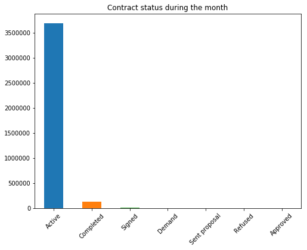

```python
credit_card.NAME_CONTRACT_STATUS.value_counts().plot(kind='bar', rot=45, figsize=(8,6), title='Contract status during the month')
```